# Spatially-explicit model of cosmogenic nuclide production in sediments

Nicolas Gauthier and Nari Miller

Last updated: February, 2018

```r
library(tidyverse)
library(stringr)
library(rgrass7)
```

## Model specification

We use the following model for $P_z$, the production rate of $^{10}$Be at depth $z$:
$$P_z = P_0 e^{-z\frac{\rho}{\Lambda_{spal}}} - N\lambda$$
with parameters:

$P_0$ is the production rate of Beryllium-10 in quartz at sea level

```r
P_0 <- 4.49     # [at/g/yr] after Stone, 1999.
```

$\lambda$ is the decay constant for $^{10}$Be

```r
ltlambda <- log(2) / 1.5e6
```

$L$ is the attenuation length for neutrons

```r
L <- 160    # [g/cm2]
```

$\rho$ is the density of overburden

```r
rho <- 2.6  # [ g/cm3]
```

and variables:

$N$ is the concentration of nuclides in the sample  
$z$ is the depth to that packet of sediment at time $t$  
$t$ is some length of time.

### Assumptions

For the sake of simplicity, we assume there is no topographic shielding (topographic shielding factor = 1) and a constant location in the Mediterranean at 40N 0E.

## Sample data

First we need base set of raster maps to initialize the variables.  
We create a multi-layer raster brick where each cell represents a 1 cm$^{3}$ packet of sediment, the **values()** of the cells correspond to $N$ (the concentration of nuclides in that packet), and the index of each layer corresponds to $1 + z$, the depth of that packet of sediment in cm.

```r
N0 <- rep(1, 1000)
```

## Simulation

First translate the above formula for $P_z$ into an R function that calculates the $^{10}$Be production rate given values of $N$ and $z$.

```r
P_z <- function(N, z){
  P_0 * exp(-z*rho/L) * exp(-ltlambda) - N*ltlambda
}
```

Numerically integrate the differential equation with Euler’s method. Using this function and the sample raster brick, iterate over a period of 100 years.

```r
nsim <- 100 # simulation length

N <- N0 # initial conditions

record <- data_frame(time = 0, depth = 1:length(N) - .5, value = N)

for(i in 1:nsim){
  delta <- P_z(N, (1:length(N) - .5))
  N <- N + delta
  record <- data_frame(time = i, depth = 1:length(N) - .5, value = N) %>%
    bind_rows(record, .)
}
```

Plot the resulting solution.

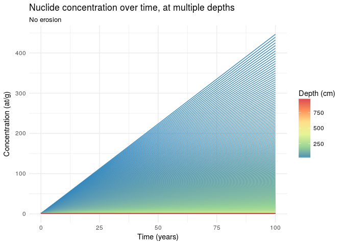

```r
ggplot(record, aes(x=time, y=value, group = as.factor(depth), color = depth)) +
  geom_line() +
  scale_color_distiller(palette = 'Spectral', name = 'Depth (cm)') +
  labs(title = 'Nuclide concentration over time, at multiple depths', subtitle = 'No erosion', x = 'Time (years)', y = 'Concentration (at/g)') +
  theme_minimal()
```

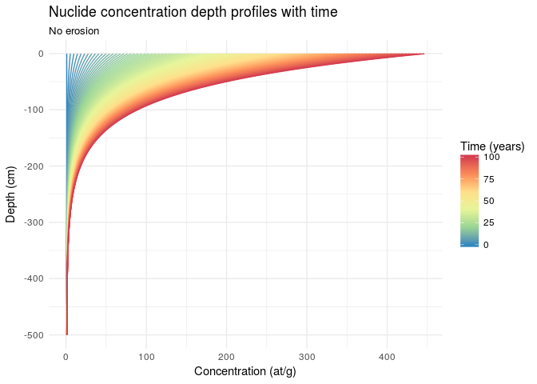

```r
record %>%
  filter(depth <= 500) %>%
ggplot(aes(x=value, y=depth * -1, group = as.factor(time), color = time)) +
  geom_line() +
  scale_color_distiller(palette = 'Spectral', name = 'Time (years)') +
  labs(title = 'Nuclide concentration depth profiles with time', subtitle = 'No erosion', x = 'Concentration (at/g)', y = 'Depth (cm)') +
  theme_minimal()
```

Now rerun the simulation, adding a constant erosion rate.

```r
N <- N0 # initial conditions
nsim <- 300
record <- data_frame(time = 0, depth = 1:length(N) - .5, value = N)
for(i in 1:nsim){
  delta <- P_z(N, (1:length(N) - .5))
  N <- N + delta
  N <- N[-1] ; N <- c(N,1)
  record <- data_frame(time = i, depth = 1:length(N) - .5, value = N) %>%
    bind_rows(record, .)
}
```

We can see that, with constant erosion, nuclide concentrations reach and equilibrium point.

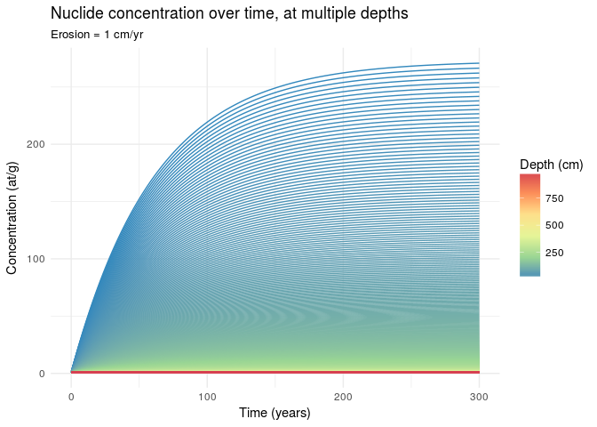

```r
ggplot(record, aes(x=time, y=value, group = as.factor(depth), color = depth)) +
  geom_line() +
  scale_color_distiller(palette = 'Spectral', name = 'Depth (cm)') +
  labs(title = 'Nuclide concentration over time, at multiple depths', subtitle = 'Erosion = 1 cm/yr', x = 'Time (years)', y = 'Concentration (at/g)') +
  theme_minimal()
```

Likewise, we can see that an equilibrium depth profile is reached.

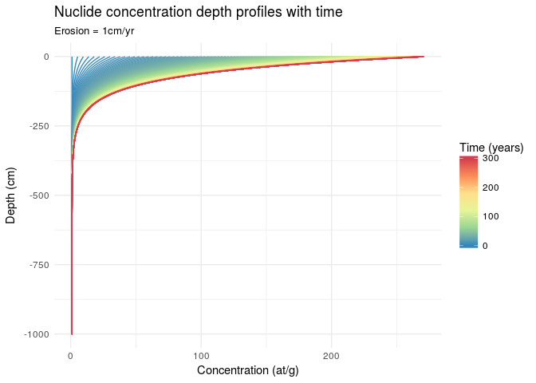

```r
ggplot(record, aes(x=value, y=depth * -1, group = as.factor(time), color = time)) +
  geom_line() +
  scale_color_distiller(palette = 'Spectral', name = 'Time (years)') +
  labs(title = 'Nuclide concentration depth profiles with time', subtitle = 'Erosion = 1cm/yr', x = 'Concentration (at/g)', y = 'Depth (cm)') +
  theme_minimal()
```

What if erosion varies over time?

```r
set.seed(1000) # set seed for reproduceability
erosion <- runif(nsim, max = 2) %>% #randomly generate a series of erosion and deposition rates
  as.integer

N <- N0 # initial conditions
record <- data_frame(time = 0, depth = 1:length(N) - .5, value = N)
for(i in 1:nsim){
  delta <- P_z(N, (1:length(N) - .5))
  N <- N + delta
  e <- erosion[i]
  if(e > 0){N = N[-(1:e)]}
  record <- data_frame(time = i, depth = 1:length(N) - .5, value = N) %>%
    bind_rows(record, .)
}
```

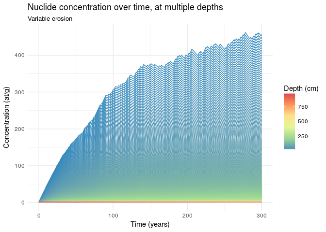

```r
ggplot(record, aes(x=time, y=value, group = as.factor(depth), color = depth)) +
  geom_line() +
  scale_color_distiller(palette = 'Spectral', name = 'Depth (cm)') +
  labs(title = 'Nuclide concentration over time, at multiple depths', subtitle = 'Variable erosion', x = 'Time (years)', y = 'Concentration (at/g)') +
  theme_minimal()
```

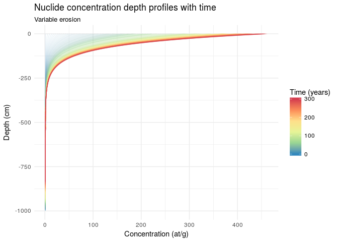

```r
ggplot(record, aes(x=value, y=depth * -1, group = as.factor(time), color = time)) +
  geom_line(alpha = .1) +
  scale_color_distiller(palette = 'Spectral', name = 'Time (years)') +
  labs(title = 'Nuclide concentration depth profiles with time', subtitle = 'Variable erosion', x = 'Concentration (at/g)', y = 'Depth (cm)') +
  theme_minimal()
```

Now include variable erosion AND deposition

```r
erosion <- rnorm(nsim, mean = -1, sd = 1.5) %>% #randomly generate a series of erosion and deposition rates
  as.integer

N <- N0 # initial conditions
record <- data_frame(time = 0, depth = 1:length(N) - .5, value = N)
for(i in 1:nsim){
  delta <- P_z(N, (1:length(N) - .5))
  N <- N + delta
  e <- erosion[i]
  if(e > 0){N <- c(rep(1, e), N)}
  if(e < 0){N = N[-(1:abs(e))]}
  record <- data_frame(time = i, depth = 1:length(N) - .5, value = N) %>%
    bind_rows(record, .)
}
```

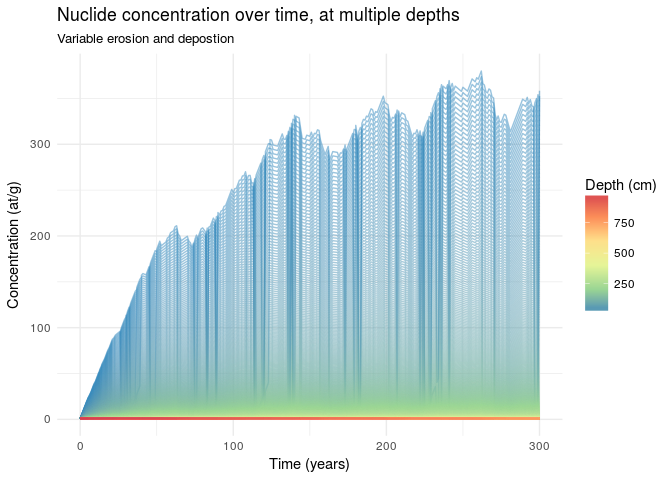

```r
ggplot(record, aes(x=time, y=value, group = as.factor(depth), color = depth)) +
  geom_line(alpha = .5) +
  scale_color_distiller(palette = 'Spectral', name = 'Depth (cm)') +
  labs(title = 'Nuclide concentration over time, at multiple depths', subtitle = 'Variable erosion and depostion', x = 'Time (years)', y = 'Concentration (at/g)') +
  theme_minimal()
```

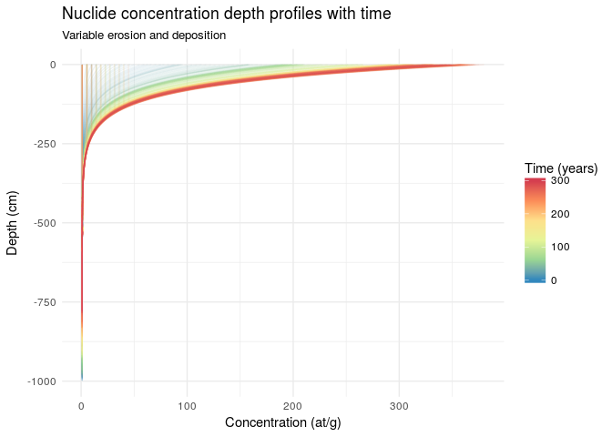

```r
ggplot(record, aes(x=value, y=depth * -1, group = as.factor(time), color = time)) +
  geom_line(alpha = .1) +
  scale_color_distiller(palette = 'Spectral', name = 'Time (years)') +
  labs(title = 'Nuclide concentration depth profiles with time', subtitle = 'Variable erosion and deposition', x = 'Concentration (at/g)', y = 'Depth (cm)') +
  theme_minimal()
```